# Actividad 3 - Regresión lineal simple para predecir G3

Métodos y Simulación Estadística - Maestría en Ciencia de Datos

Victor Hugo Perilla Martinez

2026-04-10

# 1 Índice

1. Índice
2. Exploración de datos
3. Modelo de regresión lineal simple para modelar G3 para Matemáticas y Portugués
4. Análisis Diagnóstico
5. Análisis Atípicos e influencia
6. Intervalos de confianza y predicciones
7. Discusión y conclusiones
8. Referencias
9. Anexos

# 2 Exploración de datos

Se requiere ajustar dos modelos de regresión lineal simple, con el objetivo de predecir la nota final **G3** a partir de una sola variable cuantitativa, uno para Matemáticas y otro para Lengua Portuguesa.

## 2.1 Carga, estructura y preparación de los datos

```r
mat <- read.csv("datos/student-mat.csv", sep = ";", stringsAsFactors = FALSE)
por <- read.csv("datos/student-por.csv", sep = ";", stringsAsFactors = FALSE)

variables_numericas <- c(
  "age", "Medu", "Fedu", "traveltime", "studytime", "failures", "famrel",
  "freetime", "goout", "Dalc", "Walc", "health", "absences", "G1", "G2", "G3"
)

mat_num <- mat |> dplyr::select(all_of(variables_numericas))
por_num <- por |> dplyr::select(all_of(variables_numericas))

resumen_estructura <- tibble(
  Base = c("Matemáticas", "Portugués"),
  Observaciones = c(nrow(mat), nrow(por)),
  Variables = c(ncol(mat), ncol(por)),
  Variables_numéricas = c(ncol(mat_num), ncol(por_num)),
  Faltantes_totales = c(sum(is.na(mat)), sum(is.na(por)))
)

knitr::kable(
  resumen_estructura,
  caption = "Estructura general de las bases de datos utilizadas.",
  digits = 0,
  format = "html"
) |>
  kableExtra::kable_styling(
    bootstrap_options = c("striped", "hover", "bordered"),
    full_width = FALSE,
    font_size = 12
  )
```

Table 2.1: Estructura general de las bases de datos utilizadas.

| Base | Observaciones | Variables | Variables_numéricas | Faltantes_totales |
| --- | --- | --- | --- | --- |
| Matemáticas | 395 | 33 | 16 | 0 |
| Portugués | 649 | 33 | 16 | 0 |

En la Tabla 2.1 se observa que las dos bases conservan la misma estructura de 33 columnas y no presentan valores faltantes. No fue necesario imputar ni eliminar registros. Las variables a analizar son las de la tabla 2.2

```r
diccionario <- tibble(
  Variable = c(
    "age", "Medu", "Fedu", "traveltime", "studytime", "failures", "famrel",
    "freetime", "goout", "Dalc", "Walc", "health", "absences", "G1", "G2", "G3"
  ),
  Descripcion = c(
    "Edad del estudiante",
    "Escolaridad de la madre",
    "Escolaridad del padre",
    "Tiempo de desplazamiento al colegio",
    "Tiempo semanal de estudio",
    "Número de cursos reprobados previamente",
    "Calidad de las relaciones familiares",
    "Tiempo libre después de clase",
    "Frecuencia de salidas con amigos",
    "Consumo de alcohol entre semana",
    "Consumo de alcohol en fin de semana",
    "Estado de salud actual",
    "Número de ausencias",
    "Nota del primer periodo",
    "Nota del segundo periodo",
    "Nota final"
  ),
  Tipo = c(rep("Cuantitativa", 16))
)

knitr::kable(
  diccionario,
  caption = "Variables cuantitativas consideradas en el análisis.",
  format = "html"
) |>
  kableExtra::kable_styling(
    bootstrap_options = c("striped", "hover", "bordered"),
    full_width = FALSE,
    font_size = 12
  ) |>
  kableExtra::scroll_box(height = "100%")
```

Table 2.2: Variables cuantitativas consideradas en el análisis.

| Variable | Descripcion | Tipo |
| --- | --- | --- |
| age | Edad del estudiante | Cuantitativa |
| Medu | Escolaridad de la madre | Cuantitativa |
| Fedu | Escolaridad del padre | Cuantitativa |
| traveltime | Tiempo de desplazamiento al colegio | Cuantitativa |
| studytime | Tiempo semanal de estudio | Cuantitativa |
| failures | Número de cursos reprobados previamente | Cuantitativa |
| famrel | Calidad de las relaciones familiares | Cuantitativa |
| freetime | Tiempo libre después de clase | Cuantitativa |
| goout | Frecuencia de salidas con amigos | Cuantitativa |
| Dalc | Consumo de alcohol entre semana | Cuantitativa |
| Walc | Consumo de alcohol en fin de semana | Cuantitativa |
| health | Estado de salud actual | Cuantitativa |
| absences | Número de ausencias | Cuantitativa |
| G1 | Nota del primer periodo | Cuantitativa |
| G2 | Nota del segundo periodo | Cuantitativa |
| G3 | Nota final | Cuantitativa |

## 2.2 Exploración inicial y selección de predictores

```r
# Variables cuantitativas a resumir
variables_cuantitativas <- c(
  "age", "Medu", "Fedu", "traveltime", "studytime", "failures", "famrel",
  "freetime", "goout", "Dalc", "Walc", "health", "absences", "G1", "G2", "G3"
)

# Función de resumen descriptivo por variable
resumen_variable <- function(df, nombre_base, var_name) {

  x <- df[[var_name]]

  q1  <- quantile(x, 0.25, na.rm = TRUE)
  q2  <- quantile(x, 0.50, na.rm = TRUE)
  q3  <- quantile(x, 0.75, na.rm = TRUE)
  p10 <- quantile(x, 0.10, na.rm = TRUE)
  p90 <- quantile(x, 0.90, na.rm = TRUE)
  iqr <- IQR(x, na.rm = TRUE)

  lim_inf <- q1 - 1.5 * iqr
  lim_sup <- q3 + 1.5 * iqr

  tibble(
    Base = nombre_base,
    Variable = var_name,
    Media = mean(x, na.rm = TRUE),
    Mediana = median(x, na.rm = TRUE),
    DE = sd(x, na.rm = TRUE),
    CV = ifelse(mean(x, na.rm = TRUE) == 0, NA, sd(x, na.rm = TRUE) / mean(x, na.rm = TRUE) * 100),
    Skewness = e1071::skewness(x, na.rm = TRUE, type = 2),
    Kurtosis = e1071::kurtosis(x, na.rm = TRUE, type = 2),
    Min = min(x, na.rm = TRUE),
    P10 = p10,
    Q1 = q1,
    Q2 = q2,
    Q3 = q3,
    P90 = p90,
    Max = max(x, na.rm = TRUE),
    IQR = iqr,
    Lim_inf_outlier = lim_inf,
    Lim_sup_outlier = lim_sup,
    Outliers_bajos = sum(x < lim_inf, na.rm = TRUE),
    Outliers_altos = sum(x > lim_sup, na.rm = TRUE),
    Outliers_total = sum(x < lim_inf | x > lim_sup, na.rm = TRUE)
  )
}

# Tabla completa para Matemáticas y Portugués
tabla_descriptiva <- bind_rows(
  map_dfr(variables_cuantitativas, ~ resumen_variable(mat, "Matemáticas", .x)),
  map_dfr(variables_cuantitativas, ~ resumen_variable(por, "Portugués", .x))
)

knitr::kable(
  tabla_descriptiva,
  caption = "Resumen descriptivo ampliado de todas las variables cuantitativas en Matemáticas y Portugués, incluyendo asimetría, curtosis y detección de valores atípicos.",
  digits = 2,
  format = "html"
) |>
  kableExtra::kable_styling(
    bootstrap_options = c("striped", "hover", "bordered"),
    full_width = FALSE,
    font_size = 10
  ) |>
  kableExtra::scroll_box(width = "100%", height = "100%")
```

Table 2.3: Resumen descriptivo ampliado de todas las variables cuantitativas en Matemáticas y Portugués, incluyendo asimetría, curtosis y detección de valores atípicos.

| Base | Variable | Media | Mediana | DE | CV | Skewness | Kurtosis | Min | P10 | Q1 | Q2 | Q3 | P90 | Max | IQR | Lim_inf_outlier | Lim_sup_outlier | Outliers_bajos | Outliers_altos | Outliers_total |
| --- | --- | --- | --- | --- | --- | --- | --- | --- | --- | --- | --- | --- | --- | --- | --- | --- | --- | --- | --- | --- |
| Matemáticas | age | 16.70 | 17 | 1.28 | 7.64 | 0.47 | 0.00 | 15 | 15.0 | 16 | 17 | 18 | 18.0 | 22 | 2 | 13.0 | 21.0 | 0 | 1 | 1 |
| Matemáticas | Medu | 2.75 | 3 | 1.09 | 39.82 | -0.32 | -1.09 | 0 | 1.0 | 2 | 3 | 4 | 4.0 | 4 | 2 | -1.0 | 7.0 | 0 | 0 | 0 |
| Matemáticas | Fedu | 2.52 | 2 | 1.09 | 43.16 | -0.03 | -1.20 | 0 | 1.0 | 2 | 2 | 3 | 4.0 | 4 | 1 | 0.5 | 4.5 | 2 | 0 | 2 |
| Matemáticas | traveltime | 1.45 | 1 | 0.70 | 48.17 | 1.61 | 2.34 | 1 | 1.0 | 1 | 1 | 2 | 2.0 | 4 | 1 | -0.5 | 3.5 | 0 | 8 | 8 |
| Matemáticas | studytime | 2.04 | 2 | 0.84 | 41.23 | 0.63 | -0.01 | 1 | 1.0 | 1 | 2 | 2 | 3.0 | 4 | 1 | -0.5 | 3.5 | 0 | 27 | 27 |
| Matemáticas | failures | 0.33 | 0 | 0.74 | 222.53 | 2.39 | 5.00 | 0 | 0.0 | 0 | 0 | 0 | 1.0 | 3 | 0 | 0.0 | 0.0 | 0 | 83 | 83 |
| Matemáticas | famrel | 3.94 | 4 | 0.90 | 22.73 | -0.95 | 1.14 | 1 | 3.0 | 4 | 4 | 5 | 5.0 | 5 | 1 | 2.5 | 6.5 | 26 | 0 | 26 |
| Matemáticas | freetime | 3.24 | 3 | 1.00 | 30.87 | -0.16 | -0.30 | 1 | 2.0 | 3 | 3 | 4 | 4.6 | 5 | 1 | 1.5 | 5.5 | 19 | 0 | 19 |
| Matemáticas | goout | 3.11 | 3 | 1.11 | 35.81 | 0.12 | -0.77 | 1 | 2.0 | 2 | 3 | 4 | 5.0 | 5 | 2 | -1.0 | 7.0 | 0 | 0 | 0 |
| Matemáticas | Dalc | 1.48 | 1 | 0.89 | 60.14 | 2.19 | 4.76 | 1 | 1.0 | 1 | 1 | 2 | 3.0 | 5 | 1 | -0.5 | 3.5 | 0 | 18 | 18 |
| Matemáticas | Walc | 2.29 | 2 | 1.29 | 56.21 | 0.61 | -0.79 | 1 | 1.0 | 1 | 2 | 3 | 4.0 | 5 | 2 | -2.0 | 6.0 | 0 | 0 | 0 |
| Matemáticas | health | 3.55 | 4 | 1.39 | 39.11 | -0.49 | -1.01 | 1 | 1.0 | 3 | 4 | 5 | 5.0 | 5 | 2 | 0.0 | 8.0 | 0 | 0 | 0 |
| Matemáticas | absences | 5.71 | 4 | 8.00 | 140.19 | 3.67 | 21.72 | 0 | 0.0 | 0 | 4 | 8 | 14.0 | 75 | 8 | -12.0 | 20.0 | 0 | 15 | 15 |
| Matemáticas | G1 | 10.91 | 11 | 3.32 | 30.43 | 0.24 | -0.69 | 3 | 7.0 | 8 | 11 | 13 | 16.0 | 19 | 5 | 0.5 | 20.5 | 0 | 0 | 0 |
| Matemáticas | G2 | 10.71 | 11 | 3.76 | 35.11 | -0.43 | 0.63 | 0 | 6.0 | 9 | 11 | 13 | 15.0 | 19 | 4 | 3.0 | 19.0 | 13 | 0 | 13 |
| Matemáticas | G3 | 10.42 | 11 | 4.58 | 43.99 | -0.73 | 0.40 | 0 | 5.0 | 8 | 11 | 14 | 15.6 | 20 | 6 | -1.0 | 23.0 | 0 | 0 | 0 |
| Portugués | age | 16.74 | 17 | 1.22 | 7.27 | 0.42 | 0.07 | 15 | 15.0 | 16 | 17 | 18 | 18.0 | 22 | 2 | 13.0 | 21.0 | 0 | 1 | 1 |
| Portugués | Medu | 2.51 | 2 | 1.13 | 45.12 | -0.03 | -1.26 | 0 | 1.0 | 2 | 2 | 4 | 4.0 | 4 | 2 | -1.0 | 7.0 | 0 | 0 | 0 |
| Portugués | Fedu | 2.31 | 2 | 1.10 | 47.69 | 0.22 | -1.11 | 0 | 1.0 | 1 | 2 | 3 | 4.0 | 4 | 2 | -2.0 | 6.0 | 0 | 0 | 0 |
| Portugués | traveltime | 1.57 | 1 | 0.75 | 47.73 | 1.25 | 1.11 | 1 | 1.0 | 1 | 1 | 2 | 3.0 | 4 | 1 | -0.5 | 3.5 | 0 | 16 | 16 |
| Portugués | studytime | 1.93 | 2 | 0.83 | 42.97 | 0.70 | 0.04 | 1 | 1.0 | 1 | 2 | 2 | 3.0 | 4 | 1 | -0.5 | 3.5 | 0 | 35 | 35 |
| Portugués | failures | 0.22 | 0 | 0.59 | 267.37 | 3.09 | 9.82 | 0 | 0.0 | 0 | 0 | 0 | 1.0 | 3 | 0 | 0.0 | 0.0 | 0 | 100 | 100 |
| Portugués | famrel | 3.93 | 4 | 0.96 | 24.31 | -1.11 | 1.35 | 1 | 3.0 | 4 | 4 | 5 | 5.0 | 5 | 1 | 2.5 | 6.5 | 51 | 0 | 51 |
| Portugués | freetime | 3.18 | 3 | 1.05 | 33.05 | -0.18 | -0.40 | 1 | 2.0 | 3 | 3 | 4 | 5.0 | 5 | 1 | 1.5 | 5.5 | 45 | 0 | 45 |
| Portugués | goout | 3.18 | 3 | 1.18 | 36.92 | -0.01 | -0.87 | 1 | 2.0 | 2 | 3 | 4 | 5.0 | 5 | 2 | -1.0 | 7.0 | 0 | 0 | 0 |
| Portugués | Dalc | 1.50 | 1 | 0.92 | 61.56 | 2.14 | 4.35 | 1 | 1.0 | 1 | 1 | 2 | 3.0 | 5 | 1 | -0.5 | 3.5 | 0 | 34 | 34 |
| Portugués | Walc | 2.28 | 2 | 1.28 | 56.32 | 0.64 | -0.77 | 1 | 1.0 | 1 | 2 | 3 | 4.0 | 5 | 2 | -2.0 | 6.0 | 0 | 0 | 0 |
| Portugués | health | 3.54 | 4 | 1.45 | 40.90 | -0.50 | -1.12 | 1 | 1.0 | 2 | 4 | 5 | 5.0 | 5 | 3 | -2.5 | 9.5 | 0 | 0 | 0 |
| Portugués | absences | 3.66 | 2 | 4.64 | 126.81 | 2.02 | 5.78 | 0 | 0.0 | 0 | 2 | 6 | 10.0 | 32 | 6 | -9.0 | 15.0 | 0 | 21 | 21 |
| Portugués | G1 | 11.40 | 11 | 2.75 | 24.08 | 0.00 | 0.04 | 0 | 8.0 | 10 | 11 | 13 | 15.0 | 19 | 3 | 5.5 | 17.5 | 8 | 8 | 16 |
| Portugués | G2 | 11.57 | 11 | 2.91 | 25.18 | -0.36 | 1.66 | 0 | 8.0 | 10 | 11 | 13 | 15.0 | 19 | 3 | 5.5 | 17.5 | 10 | 15 | 25 |
| Portugués | G3 | 11.91 | 12 | 3.23 | 27.13 | -0.91 | 2.71 | 0 | 8.8 | 10 | 12 | 14 | 16.0 | 19 | 4 | 4.0 | 20.0 | 16 | 0 | 16 |

En la Tabla 2.3 se evidencia que la variable respuesta **G3** presenta asimetría negativa en ambas asignaturas, lo que indica concentración de observaciones en calificaciones medias y altas. Además, en Matemáticas se observa mayor dispersión relativa (CV ≈ 44%) que en Portugués (CV ≈ 27%), sugiriendo una respuesta más variable y, por tanto, potencialmente más difícil de predecir.

En cuanto a valores atípicos, no se identifican en Matemáticas, mientras que en Portugués existen outliers bajos, lo cual puede afectar la estimación de modelos lineales y deberá considerarse en el análisis de residuos.

Respecto a las variables predictoras, se identifican como poco informativas aquellas con alta dispersión relativa o baja variabilidad efectiva, como **absences**, **health**, **freetime**, **goout** y **famrel**, las cuales presentan distribuciones altamente sesgadas o concentradas que limitan su capacidad explicativa.

Por el contrario, variables como **G2** y **G1** muestran un patrón más consistente con la variable respuesta, por lo que resultan candidatas naturales para el ajuste del modelo. Asimismo, variables como **studytime** y el nivel educativo de los padres (**Medu**, **Fedu**) conservan interés teórico y cierta estabilidad estadística, aunque con menor capacidad explicativa que las calificaciones previas.

En conjunto, las demás variables podrían aportar información complementaria, pero su uso como único predictor en un modelo lineal simple sería menos robusto que el de **G2** o **G1**, tanto por su menor asociación con la respuesta como por su patrón distributivo menos favorable.

A partir de esta exploración descriptiva y de la comparación entre variables cuantitativas, el siguiente paso consiste en evaluar formalmente la asociación entre **G3** y cada predictor potencial, con el fin de seleccionar la variable que ofrezca mayor capacidad explicativa dentro de la restricción metodológica de usar una sola covariable cuantitativa.

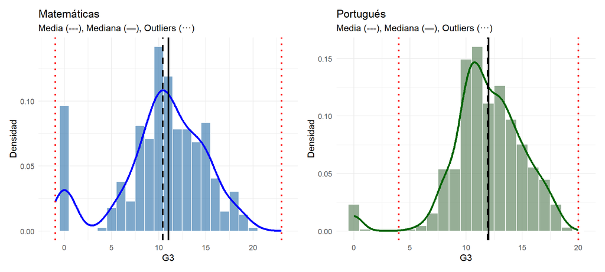

Figure 2.1: Distribución de la nota final G3 en Matemáticas y Portugués con densidad, tendencia central y límites de outliers.

```r
# Estadísticos Matemáticas
media_mat <- mean(mat$G3)
mediana_mat <- median(mat$G3)
q1_mat <- quantile(mat$G3, 0.25)
q3_mat <- quantile(mat$G3, 0.75)
iqr_mat <- IQR(mat$G3)
lim_inf_mat <- q1_mat - 1.5 * iqr_mat
lim_sup_mat <- q3_mat + 1.5 * iqr_mat

# Estadísticos Portugués
media_por <- mean(por$G3)
mediana_por <- median(por$G3)
q1_por <- quantile(por$G3, 0.25)
q3_por <- quantile(por$G3, 0.75)
iqr_por <- IQR(por$G3)
lim_inf_por <- q1_por - 1.5 * iqr_por
lim_sup_por <- q3_por + 1.5 * iqr_por


# Gráfico Matemáticas
g1 <- ggplot(mat, aes(x = G3)) +
  geom_histogram(aes(y = after_stat(density)),
                 binwidth = 1, fill = "steelblue",
                 color = "white", alpha = 0.7) +
  geom_density(color = "blue", linewidth = 1.2, alpha = 0.4) +
  geom_vline(xintercept = media_mat, linetype = "dashed", color = "black", linewidth = 1) +
  geom_vline(xintercept = mediana_mat, linetype = "solid", color = "black", linewidth = 1) +
  geom_vline(xintercept = lim_inf_mat, linetype = "dotted", color = "red", linewidth = 1) +
  geom_vline(xintercept = lim_sup_mat, linetype = "dotted", color = "red", linewidth = 1) +
  labs(title = "Matemáticas",
       subtitle = "Media (---), Mediana (—), Outliers (···)",
       x = "G3", y = "Densidad") +
  theme_minimal()


# Gráfico Portugués
g2 <- ggplot(por, aes(x = G3)) +
  geom_histogram(aes(y = after_stat(density)),
                 binwidth = 1, fill = "darkseagreen4",
                 color = "white", alpha = 0.7) +
  geom_density(color = "darkgreen", linewidth = 1.2, alpha = 0.4) +
  geom_vline(xintercept = media_por, linetype = "dashed", color = "black", linewidth = 1) +
  geom_vline(xintercept = mediana_por, linetype = "solid", color = "black", linewidth = 1) +
  geom_vline(xintercept = lim_inf_por, linetype = "dotted", color = "red", linewidth = 1) +
  geom_vline(xintercept = lim_sup_por, linetype = "dotted", color = "red", linewidth = 1) +
  labs(title = "Portugués",
       subtitle = "Media (---), Mediana (—), Outliers (···)",
       x = "G3", y = "Densidad") +
  theme_minimal()

g1 + g2
```

En la Figura 2.1, la variable **G3** se observa discreta y acotada entre 0 y 20, con concentración en valores intermedios y altos. Este rasgo es importante porque anticipa que la normalidad de los errores podría no cumplirse de forma estricta, incluso si la relación lineal con el predictor resultara fuerte. Además, se aprecian valores atípicos bajos en Portugués y presencia visible de notas muy bajas, incluidos algunos ceros, en Matemáticas.

Para seleccionar la variable explicativa se calcularon correlaciones de Pearson y Spearman entre **G3** y todas las variables cuantitativas disponibles. Se priorizó Pearson por su coherencia con el objetivo de ajustar una regresión lineal simple, mientras que Spearman se utilizó como contraste de robustez, dado que varias covariables provienen de escalas discretas u ordinales.

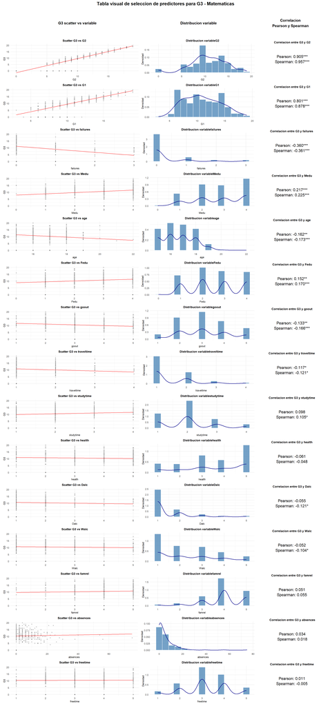

Figure 2.2: Tabla visual de seleccion de predictores para G3 - Matematicas

```r
# Variables cuantitativas predictoras
vars_y <- c(
  "age", "Medu", "Fedu", "traveltime", "studytime", "failures", "famrel",
  "freetime", "goout", "Dalc", "Walc", "health", "absences", "G1", "G2"
)

# Función para asteriscos
signif_stars <- function(p) {
  if (is.na(p)) {
    ""
  } else if (p < 0.001) {
    "***"
  } else if (p < 0.01) {
    "**"
  } else if (p < 0.05) {
    "*"
  } else {
    ""
  }
}

# Resumen de correlaciones para ordenar
tabla_corr <- tibble(variable = vars_y) |>
  mutate(
    pearson = map_dbl(variable, ~ cor(mat[[.x]], mat$G3, method = "pearson", use = "complete.obs")),
    spearman = map_dbl(variable, ~ cor(mat[[.x]], mat$G3, method = "spearman", use = "complete.obs")),
    abs_pearson = abs(pearson),
    p_pearson = map_dbl(variable, ~ cor.test(mat[[.x]], mat$G3, method = "pearson")$p.value),
    p_spearman = map_dbl(variable, ~ cor.test(mat[[.x]], mat$G3, method = "spearman", exact = FALSE)$p.value)
  ) |>
  arrange(desc(abs_pearson))

# Función para construir cada fila
crear_fila <- function(var_name, pearson, spearman, p_pearson, p_spearman) {

  datos_var <- tibble(
    G3 = mat$G3,
    variable = mat[[var_name]]
  )

  # Columna 1: Scatter G3 vs variable
  p_scatter <- ggplot(datos_var, aes(x = variable, y = G3)) +
    geom_point(alpha = 0.30, size = 0.9, color = "gray30") +
    geom_smooth(method = "lm", se = FALSE, color = "red", linewidth = 0.5) +
    labs(
      title = paste0("Scatter G3 vs ",var_name),
      x = var_name,
      y = "G3"
    ) +
    theme_minimal(base_size = 9) +
    theme(
      plot.title = element_text(size = 9, face = "bold", hjust = 0.5),
      axis.title = element_text(size = 8),
      axis.text = element_text(size = 7)
    )

  # Columna 2: Distribución de la variable
  p_dist <- ggplot(datos_var, aes(x = variable)) +
    geom_histogram(aes(y = after_stat(density)),
                   bins = 15, fill = "steelblue", color = "white", alpha = 0.75) +
    geom_density(color = "darkblue", linewidth = 0.6, alpha = 0.6) +
    labs(
      title = paste0("Distribucion variable",var_name),
      x = var_name,
      y = "Densidad"
    ) +
    theme_minimal(base_size = 9) +
    theme(
      plot.title = element_text(size = 9, face = "bold", hjust = 0.5),
      axis.title = element_text(size = 8),
      axis.text = element_text(size = 7)
    )

  # Columna 3: Texto de correlaciones
  texto_corr <- paste0(
    "Pearson: ", sprintf("%.3f", pearson), signif_stars(p_pearson), "\n",
    "Spearman: ", sprintf("%.3f", spearman), signif_stars(p_spearman)
  )

  p_corr <- ggplot() +
    annotate("text", x = 0.5, y = 0.5, label = texto_corr,
             size = 4.2, hjust = 0.5, vjust = 0.5, lineheight = 1.1) +
    xlim(0, 1) + ylim(0, 1) +
    theme_void() +
    labs(title = paste0("Correlacion entre G3 y ", var_name)) +
    theme(
      plot.title = element_text(size = 9, face = "bold", hjust = 0.5)
    )



  p_scatter + p_dist + p_corr +  plot_layout(widths = c(3.2, 2.6, 1.8))
}

# Crear todas las filas
filas_plots <- pmap(
  list(
    tabla_corr$variable,
    tabla_corr$pearson,
    tabla_corr$spearman,
    tabla_corr$p_pearson,
    tabla_corr$p_spearman
  ),
  crear_fila
)

# Encabezado general
header1 <- ggplot() +
  annotate("text", x = 0.5, y = 0.5, label = "G3 scatter vs variable",
           size = 4, fontface = "bold") +
  xlim(0, 1) + ylim(0, 1) + theme_void()

header2 <- ggplot() +
  annotate("text", x = 0.5, y = 0.5, label = "Distribucion variable",
           size = 4, fontface = "bold") +
  xlim(0, 1) + ylim(0, 1) + theme_void()

header3 <- ggplot() +
  annotate("text", x = 0.5, y = 0.5, label = "Correlacion\nPearson y Spearman",
           size = 4, fontface = "bold") +
  xlim(0, 1) + ylim(0, 1) + theme_void()


encabezado <- header1 + header2 + header3  +
  plot_layout(widths = c(3.2, 2.6, 1.8))

# Unir encabezado + filas
grafico_final <- wrap_plots(c(list(encabezado), filas_plots), ncol = 1) +
  plot_annotation(
    title = "Tabla visual de seleccion de predictores para G3 - Matematicas",
    theme = theme(
      plot.title = element_text(size = 14, face = "bold", hjust = 0.5)
    )
  )

grafico_final
```

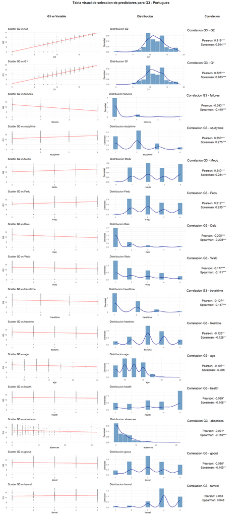

Figure 2.3: Tabla visual de seleccion de predictores para G3 - Portugues

```r
# Variables cuantitativas predictoras (las mismas)
vars_y <- c(
  "age", "Medu", "Fedu", "traveltime", "studytime", "failures", "famrel",
  "freetime", "goout", "Dalc", "Walc", "health", "absences", "G1", "G2"
)

# Función para asteriscos
signif_stars <- function(p) {
  if (is.na(p)) {
    ""
  } else if (p < 0.001) {
    "***"
  } else if (p < 0.01) {
    "**"
  } else if (p < 0.05) {
    "*"
  } else {
    ""
  }
}

tabla_corr <- tibble(variable = vars_y) |>
  dplyr::mutate(
    pearson = map_dbl(variable, ~ cor(por[[.x]], por$G3, method = "pearson", use = "complete.obs")),
    spearman = map_dbl(variable, ~ cor(por[[.x]], por$G3, method = "spearman", use = "complete.obs")),
    abs_pearson = abs(pearson),
    p_pearson = map_dbl(variable, ~ cor.test(por[[.x]], por$G3, method = "pearson")$p.value),
    p_spearman = map_dbl(variable, ~ cor.test(por[[.x]], por$G3, method = "spearman", exact = FALSE)$p.value)
  ) |>
  dplyr::arrange(desc(abs_pearson))

# Función para construir cada fila
crear_fila <- function(var_name, pearson, spearman, p_pearson, p_spearman) {

  datos_var <- tibble(
    G3 = por$G3,
    variable = por[[var_name]]
  )

  # Scatter
  p_scatter <- ggplot(datos_var, aes(x = variable, y = G3)) +
    geom_point(alpha = 0.30, size = 0.9, color = "gray30") +
    geom_smooth(method = "lm", se = FALSE, color = "red", linewidth = 0.5) +
    labs(
      title = paste0("Scatter G3 vs ", var_name),
      x = var_name,
      y = "G3"
    ) +
    theme_minimal(base_size = 9)

  # Distribución
  p_dist <- ggplot(datos_var, aes(x = variable)) +
    geom_histogram(aes(y = after_stat(density)),
                   bins = 15, fill = "steelblue", color = "white", alpha = 0.75) +
    geom_density(color = "darkblue", linewidth = 0.6, alpha = 0.6) +
    labs(
      title = paste0("Distribucion ", var_name),
      x = var_name,
      y = "Densidad"
    ) +
    theme_minimal(base_size = 9)

  # Correlaciones
  texto_corr <- paste0(
    "Pearson: ", sprintf("%.3f", pearson), signif_stars(p_pearson), "\n",
    "Spearman: ", sprintf("%.3f", spearman), signif_stars(p_spearman)
  )

  p_corr <- ggplot() +
    annotate("text", x = 0.5, y = 0.5, label = texto_corr,
             size = 4.2, hjust = 0.5, vjust = 0.5) +
    xlim(0, 1) + ylim(0, 1) +
    theme_void() +
    labs(title = paste0("Correlacion G3 - ", var_name))

  p_scatter + p_dist + p_corr + plot_layout(widths = c(3.2, 2.6, 1.8))
}

# Construcción
filas_plots <- pmap(
  list(
    tabla_corr$variable,
    tabla_corr$pearson,
    tabla_corr$spearman,
    tabla_corr$p_pearson,
    tabla_corr$p_spearman
  ),
  crear_fila
)

# Encabezado
header1 <- ggplot() +
  annotate("text", x = 0.5, y = 0.5, label = "G3 vs Variable",
           size = 4, fontface = "bold") +
  xlim(0, 1) + ylim(0, 1) + theme_void()

header2 <- ggplot() +
  annotate("text", x = 0.5, y = 0.5, label = "Distribucion",
           size = 4, fontface = "bold") +
  xlim(0, 1) + ylim(0, 1) + theme_void()

header3 <- ggplot() +
  annotate("text", x = 0.5, y = 0.5, label = "Correlacion",
           size = 4, fontface = "bold") +
  xlim(0, 1) + ylim(0, 1) + theme_void()

encabezado <- header1 + header2 + header3 +
  plot_layout(widths = c(3.2, 2.6, 1.8))

# Gráfico final
grafico_final <- wrap_plots(c(list(encabezado), filas_plots), ncol = 1) +
  plot_annotation(
    title = "Tabla visual de seleccion de predictores para G3 - Portugues",
    theme = theme(
      plot.title = element_text(size = 14, face = "bold", hjust = 0.5)
    )
  )

grafico_final
```

Las Figuras 2.2 y 2.3 muestran que **G2** es la variable más asociada con **G3** en ambas asignaturas, seguida de **G1**. En Matemáticas, la correlación de Pearson entre **G2** y **G3** es cercana a 0.905, mientras que en Portugués es aproximadamente 0.919. En consecuencia, **G2** se selecciona como predictor principal del modelo final y **G1** se conserva como segunda alternativa útil para la aplicación. Como candidatos principales para comparación se consideraron **G2**, **G1**, **failures**, **studytime** y **absences**.

Con base en esta selección, se ajustan a continuación dos modelos de regresión lineal simple, uno para Matemáticas y otro para Portugués, ambos con **G3** como respuesta y **G2** como predictor.

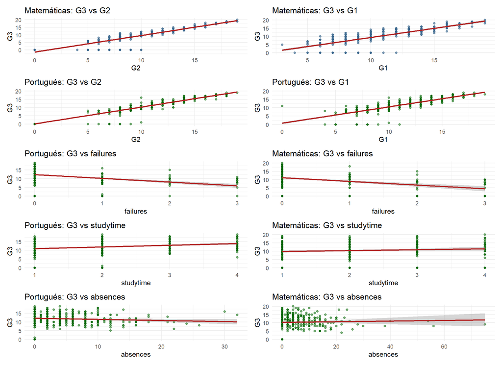

Figure 2.4: Relación de G3 con los mejores predictores cuantitativos en cada asignatura.

```r
p1 <- ggplot(mat, aes(x = G2, y = G3)) +
  geom_point(alpha = 0.65, color = "steelblue4") +
  geom_smooth(method = "lm", se = TRUE, color = "firebrick") +
  labs(title = "Matemáticas: G3 vs G2", x = "G2", y = "G3") +
  theme_minimal()

p2 <- ggplot(mat, aes(x = G1, y = G3)) +
  geom_point(alpha = 0.65, color = "steelblue4") +
  geom_smooth(method = "lm", se = TRUE, color = "firebrick") +
  labs(title = "Matemáticas: G3 vs G1", x = "G1", y = "G3") +
  theme_minimal()

p3 <- ggplot(por, aes(x = G2, y = G3)) +
  geom_point(alpha = 0.55, color = "darkgreen") +
  geom_smooth(method = "lm", se = TRUE, color = "firebrick") +
  labs(title = "Portugués: G3 vs G2", x = "G2", y = "G3") +
  theme_minimal()

p4 <- ggplot(por, aes(x = G1, y = G3)) +
  geom_point(alpha = 0.55, color = "darkgreen") +
  geom_smooth(method = "lm", se = TRUE, color = "firebrick") +
  labs(title = "Portugués: G3 vs G1", x = "G1", y = "G3") +
  theme_minimal()

p5 <- ggplot(por, aes(x = failures, y = G3)) +
  geom_point(alpha = 0.55, color = "darkgreen") +
  geom_smooth(method = "lm", se = TRUE, color = "firebrick") +
  labs(title = "Portugués: G3 vs failures", x = "failures", y = "G3") +
  theme_minimal()

p6 <- ggplot(mat, aes(x = failures, y = G3)) +
  geom_point(alpha = 0.55, color = "darkgreen") +
  geom_smooth(method = "lm", se = TRUE, color = "firebrick") +
  labs(title = "Matemáticas: G3 vs failures", x = "failures", y = "G3") +
  theme_minimal()

p7 <- ggplot(por, aes(x = studytime, y = G3)) +
  geom_point(alpha = 0.55, color = "darkgreen") +
  geom_smooth(method = "lm", se = TRUE, color = "firebrick") +
  labs(title = "Portugués: G3 vs studytime", x = "studytime", y = "G3") +
  theme_minimal()

p8 <- ggplot(mat, aes(x = studytime, y = G3)) +
  geom_point(alpha = 0.55, color = "darkgreen") +
  geom_smooth(method = "lm", se = TRUE, color = "firebrick") +
  labs(title = "Matemáticas: G3 vs studytime", x = "studytime", y = "G3") +
  theme_minimal()

p9 <- ggplot(por, aes(x = absences, y = G3)) +
  geom_point(alpha = 0.55, color = "darkgreen") +
  geom_smooth(method = "lm", se = TRUE, color = "firebrick") +
  labs(title = "Portugués: G3 vs absences", x = "absences", y = "G3") +
  theme_minimal()

p10 <- ggplot(mat, aes(x = absences, y = G3)) +
  geom_point(alpha = 0.55, color = "darkgreen") +
  geom_smooth(method = "lm", se = TRUE, color = "firebrick") +
  labs(title = "Matemáticas: G3 vs absences", x = "absences", y = "G3") +
  theme_minimal()

(p1 + p2) / (p3 + p4)/ (p5 + p6)/ (p7 + p8)/ (p9 + p10)
```

En la Figura 2.4 se observa que las variables **G2** y **G1** presentan una relación lineal positiva fuerte con G3 en ambas asignaturas, evidenciada por la alineación de los puntos alrededor de la recta de regresión, lo que confirma su alto poder predictivo. En contraste, variables como **studytime** muestran una relación positiva pero con mayor dispersión. Por su parte, **failures** y **absences** presentan una mayor variabilidad en los datos y menor alineación con la tendencia lineal.

```r
resumen_modelos <- function(df, nombre_base) {
  candidatos <- c("G2", "G1", "failures", "studytime", "absences")
  map_dfr(candidatos, function(v) {
    mod <- lm(as.formula(paste("G3 ~", v)), data = df)
    tibble(
      Base = nombre_base,
      Predictor = v,
      Correlacion = cor(df[[v]], df$G3),
      R2 = summary(mod)$r.squared,
      R2_Ajustado = summary(mod)$adj.r.squared,
      RMSE = sigma(mod),
      p_pendiente = broom::tidy(mod)$p.value[2]
    )
  }) |> arrange(desc(R2))
}

comparacion <- bind_rows(
  resumen_modelos(mat, "Matemáticas"),
  resumen_modelos(por, "Portugués")
)

knitr::kable(
  comparacion,
  caption = "Comparación de modelos lineales simples candidatos para cada asignatura.",
  digits = 4,
  format = "html"
) |>
  kableExtra::kable_styling(
    bootstrap_options = c("striped", "hover", "bordered"),
    full_width = FALSE,
    font_size = 12
  )
```

Table 2.4: Comparación de modelos lineales simples candidatos para cada asignatura.

| Base | Predictor | Correlacion | R2 | R2_Ajustado | RMSE | p_pendiente |
| --- | --- | --- | --- | --- | --- | --- |
| Matemáticas | G2 | 0.9049 | 0.8188 | 0.8183 | 1.9528 | 0.0000 |
| Matemáticas | G1 | 0.8015 | 0.6424 | 0.6414 | 2.7434 | 0.0000 |
| Matemáticas | failures | -0.3604 | 0.1299 | 0.1277 | 4.2790 | 0.0000 |
| Matemáticas | studytime | 0.0978 | 0.0096 | 0.0070 | 4.5653 | 0.0521 |
| Matemáticas | absences | 0.0342 | 0.0012 | -0.0014 | 4.5846 | 0.4973 |
| Portugués | G2 | 0.9185 | 0.8437 | 0.8435 | 1.2781 | 0.0000 |
| Portugués | G1 | 0.8264 | 0.6829 | 0.6824 | 1.8206 | 0.0000 |
| Portugués | failures | -0.3933 | 0.1547 | 0.1534 | 2.9726 | 0.0000 |
| Portugués | studytime | 0.2498 | 0.0624 | 0.0609 | 3.1307 | 0.0000 |
| Portugués | absences | -0.0914 | 0.0084 | 0.0068 | 3.2196 | 0.0199 |

# 3 Modelo de regresión lineal simple para modelar G3 para Matemáticas y Portugués

```r
mod_mat <- lm(G3 ~ G2, data = mat)
mod_por <- lm(G3 ~ G2, data = por)

coeficientes_modelo <- function(mod, nombre_base) {
  broom::tidy(mod, conf.int = TRUE) |>
    dplyr::mutate(Base = nombre_base) |>
    dplyr::select(
      Base, term, estimate, std.error, statistic, p.value, conf.low, conf.high
    )
}

tabla_coef <- dplyr::bind_rows(
  coeficientes_modelo(mod_mat, "Matemáticas"),
  coeficientes_modelo(mod_por, "Portugués")
)

knitr::kable(
  tabla_coef,
  caption = "Coeficientes estimados, pruebas t e intervalos de confianza del 95%.",
  digits = 4,
  format = "html"
) |>
  kableExtra::kable_styling(
    bootstrap_options = c("striped", "hover", "bordered"),
    full_width = FALSE,
    font_size = 12
  )
```

Table 3.1: Coeficientes estimados, pruebas t e intervalos de confianza del 95%.

| Base | term | estimate | std.error | statistic | p.value | conf.low | conf.high |
| --- | --- | --- | --- | --- | --- | --- | --- |
| Matemáticas | (Intercept) | -1.3928 | 0.2969 | -4.6904 | 0.0000 | -1.9765 | -0.8090 |
| Matemáticas | G2 | 1.1021 | 0.0262 | 42.1391 | 0.0000 | 1.0507 | 1.1535 |
| Portugués | (Intercept) | 0.1220 | 0.2056 | 0.5932 | 0.5532 | -0.2817 | 0.5257 |
| Portugués | G2 | 1.0185 | 0.0172 | 59.1040 | 0.0000 | 0.9847 | 1.0523 |

```r
pval_f <- function(mod) {
  f <- summary(mod)$fstatistic
  pf(f[1], f[2], f[3], lower.tail = FALSE)
}

resumen_global <- tibble(
  Base = c("Matemáticas", "Portugués"),
  Ecuacion = c(
    paste0("G3 = ", round(coef(mod_mat)[1], 3), " + ", round(coef(mod_mat)[2], 3), "·G2"),
    paste0("G3 = ", round(coef(mod_por)[1], 3), " + ", round(coef(mod_por)[2], 3), "·G2")
  ),
  `R²` = c(summary(mod_mat)$r.squared, summary(mod_por)$r.squared),
  `R² ajustado` = c(summary(mod_mat)$adj.r.squared, summary(mod_por)$adj.r.squared),
  `Error estándar residual` = c(sigma(mod_mat), sigma(mod_por)),
  `F` = c(summary(mod_mat)$fstatistic[1], summary(mod_por)$fstatistic[1]),
  `p valor F` = c(pval_f(mod_mat), pval_f(mod_por))
)

knitr::kable(
  resumen_global,
  caption = "Resumen del ajuste global de los modelos lineales simples seleccionados.",
  digits = 4,
  format = "html"
) |>
  kableExtra::kable_styling(
    bootstrap_options = c("striped", "hover", "bordered"),
    full_width = FALSE,
    font_size = 12
  )
```

Table 3.2: Resumen del ajuste global de los modelos lineales simples seleccionados.

| Base | Ecuacion | R² | R² ajustado | Error estándar residual | F | p valor F |
| --- | --- | --- | --- | --- | --- | --- |
| Matemáticas | G3 = -1.393 + 1.102·G2 | 0.8188 | 0.8183 | 1.9528 | 1775.707 | 0 |
| Portugués | G3 = 0.122 + 1.018·G2 | 0.8437 | 0.8435 | 1.2781 | 3493.282 | 0 |

Los resultados de las Tablas 3.1 y 3.2 muestran que, en ambas asignaturas, la pendiente asociada a G2 es positiva y altamente significativa. En Matemáticas, por cada punto adicional en G2, la nota final G3 aumenta en promedio cerca de **1.10 puntos** ; en Portugués, el incremento promedio es de **1.02 puntos**. Asimismo, los altos valores de **R²** indican que la nota del segundo periodo explica una proporción sustancial de la variabilidad observada en la nota final.

Más allá de estos resultados, es importante interpretar su significado en el contexto del problema. La fuerte relación entre G2 y G3 sugiere una alta continuidad en el desempeño académico de los estudiantes, es decir, quienes obtienen buenos resultados en el segundo periodo tienden a mantener ese rendimiento en la nota final.

Sin embargo, esta relación también debe analizarse con cautela, ya que G2 no es una variable externa o explicativa en sentido amplio, sino una medida del mismo proceso académico en una etapa previa. Esto implica que el modelo tiene una alta capacidad predictiva, pero limitada capacidad explicativa sobre las causas del rendimiento.

En este sentido, aunque el modelo es útil para predecir la nota final, no permite comprender completamente los factores que influyen en el desempeño de los estudiantes, lo que sugiere la necesidad de incorporar otras variables que capturen dimensiones adicionales del contexto educativo.

# 4 Análisis Diagnóstico

```r
interpretar_p <- function(p) {
  ifelse(p > 0.05,
         paste0(round(p, 5), " (Cumple)"),
         paste0(round(p, 5), " (No cumple)"))
}

diagnostico_modelo <- function(mod, nombre_base) {

  shapiro_p <- shapiro.test(residuals(mod))$p.value
  bp_p <- lmtest::bptest(mod)$p.value
  dw <- lmtest::dwtest(mod)

  tibble(
    Base = nombre_base,
    `Shapiro p-valor (Normalidad)` = interpretar_p(shapiro_p),
    `Breusch-Pagan p-valor (Homocedasticidad)` = interpretar_p(bp_p),
    `Durbin-Watson p-valor (Independencia)` = interpretar_p(dw$p.value),
    `Durbin-Watson estadístico (Independencia)` =
      paste0(round(unname(dw$statistic), 5))
  )
}

diagnosticos <- bind_rows(
  diagnostico_modelo(mod_mat, "Matemáticas"),
  diagnostico_modelo(mod_por, "Portugués")
)

diagnosticos_t <- diagnosticos |>
  pivot_longer(-Base, names_to = "Prueba", values_to = "Valor") |>
  pivot_wider(names_from = Base, values_from = Valor)

knitr::kable(
  diagnosticos_t,
  caption = "Pruebas de diagnóstico del modelo según supuestos.",
  format = "html"
) |>
  kableExtra::kable_styling(
    bootstrap_options = c("striped", "hover", "bordered"),
    full_width = FALSE,
    font_size = 12
  )
```

Table 4.1: Pruebas de diagnóstico del modelo según supuestos.

| Prueba | Matemáticas | Portugués |
| --- | --- | --- |
| Shapiro p-valor (Normalidad) | 0 (No cumple) | 0 (No cumple) |
| Breusch-Pagan p-valor (Homocedasticidad) | 0.00011 (No cumple) | 7e-05 (No cumple) |
| Durbin-Watson p-valor (Independencia) | 0.09125 (Cumple) | 0.02463 (No cumple) |
| Durbin-Watson estadístico (Independencia) | 1.86639 | 1.8464 |

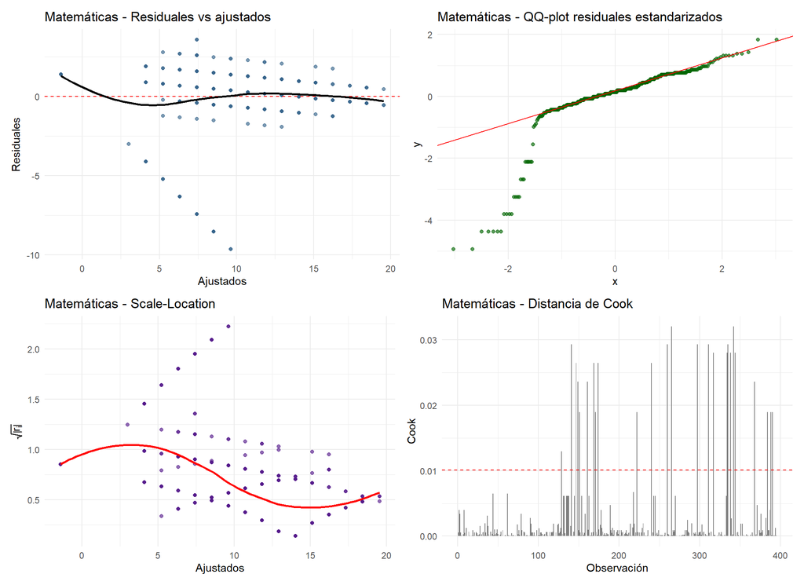

Figure 4.1: Diagnóstico gráfico de los modelos finales Matemáticas.

```r
plot_diag <- function(mod, nombre_base) {
  datos_diag <- broom::augment(mod) |>
    mutate(indice = row_number())

  g_res <- ggplot(datos_diag, aes(x = .fitted, y = .resid)) +
    geom_point(alpha = 0.65, color = "steelblue4") +
    geom_hline(yintercept = 0, linetype = "dashed", color = "red") +
    geom_smooth(se = FALSE, color = "black", method = "loess") +
    labs(title = paste(nombre_base, "- Residuales vs ajustados"), x = "Ajustados", y = "Residuales") +
    theme_minimal()

  g_qq <- ggplot(datos_diag, aes(sample = .std.resid)) +
    stat_qq(color = "darkgreen", alpha = 0.65) +
    stat_qq_line(color = "red") +
    labs(title = paste(nombre_base, "- QQ-plot residuales estandarizados")) +
    theme_minimal()

  g_scale <- ggplot(datos_diag, aes(x = .fitted, y = sqrt(abs(.std.resid)))) +
    geom_point(alpha = 0.65, color = "purple4") +
    geom_smooth(se = FALSE, color = "red", method = "loess") +
    labs(title = paste(nombre_base, "- Scale-Location"), x = "Ajustados", y = expression(sqrt(abs(r[i])))) +
    theme_minimal()

  g_cook <- ggplot(datos_diag, aes(x = indice, y = .cooksd)) +
    geom_col(fill = "grey50") +
    geom_hline(yintercept = 4 / nrow(datos_diag), linetype = "dashed", color = "red") +
    labs(title = paste(nombre_base, "- Distancia de Cook"), x = "Observación", y = "Cook") +
    theme_minimal()

  (g_res + g_qq) / (g_scale + g_cook)
}
plot_diag(mod_mat, "Matemáticas")
```

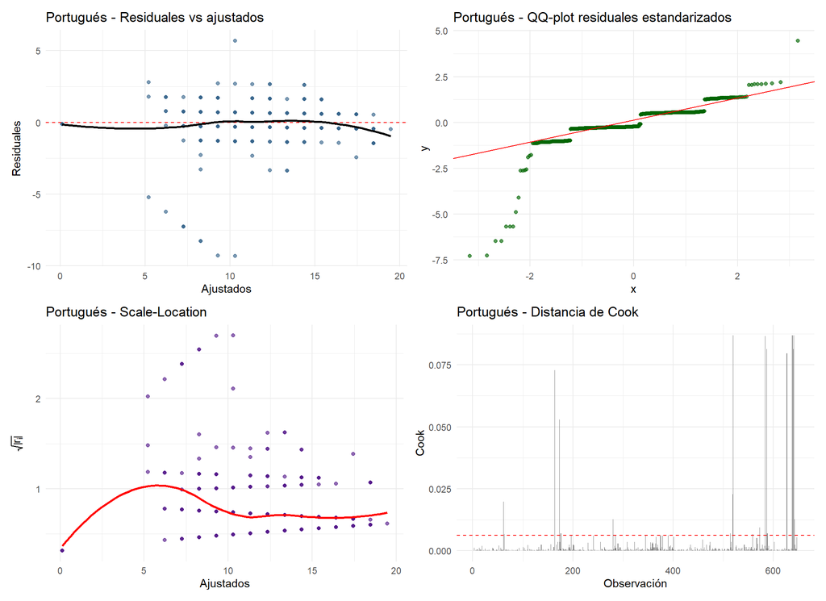

Figure 4.2: Diagnóstico gráfico de los modelos finales Portugués.

```r
plot_diag(mod_por, "Portugués")
```

El diagnóstico sugiere que los supuestos clásicos no se cumplen de forma estricta. En particular, la normalidad de los errores se rechaza en ambos modelos y la prueba de Breusch-Pagan aporta evidencia de heterocedasticidad tanto en Matemáticas como en Portugués; además, en Portugués también se detecta incumplimiento del supuesto de independencia. Se exploraron transformaciones y especificaciones alternativas, pero las mejoras obtenidas no compensaron la pérdida de interpretabilidad ni alteraron de forma sustancial la decisión final. Por ello, se mantuvo el modelo lineal simple en la escala original, reconociendo explícitamente sus limitaciones inferenciales.(ver anexos)

# 5 Análisis Atípicos e influencia

```r
resumen_influencia <- function(mod, nombre_base) {
  infl <- broom::augment(mod) |>
    mutate(
      indice = row_number(),
      leverage = hatvalues(mod),
      student = rstudent(mod),
      cook = cooks.distance(mod)
    )

  tibble(
    Base = nombre_base,
    `|Residuo studentizado| > 3` = sum(abs(infl$student) > 3),
    `Cook > 4/n` = sum(infl$cook > 4 / nrow(infl)),
    `Leverage > 2p/n` = sum(infl$leverage > (2 * 2) / nrow(infl)),
    `Máxima distancia de Cook` = max(infl$cook)
  )
}

influencia <- bind_rows(
  resumen_influencia(mod_mat, "Matemáticas"),
  resumen_influencia(mod_por, "Portugués")
)

knitr::kable(
  influencia,
  caption = "Resumen de observaciones atípicas o influyentes en los modelos finales.",
  digits = 4,
  format = "html"
) |>
  kableExtra::kable_styling(
    bootstrap_options = c("striped", "hover", "bordered"),
    full_width = FALSE,
    font_size = 12
  )
```

Table 5.1: Resumen de observaciones atípicas o influyentes en los modelos finales.

| Base | \|Residuo studentizado\| > 3 | Cook > 4/n | Leverage > 2p/n | Máxima distancia de Cook |
| --- | --- | --- | --- | --- |
| Matemáticas | 15 | 25 | 29 | 0.0321 |
| Portugués | 10 | 20 | 52 | 0.0868 |

El análisis de observaciones atípicas e influyentes muestra que, aunque existen algunos casos con influencia relativa sobre el ajuste, la mayoría no alcanza valores extremos de la distancia de Cook. En consecuencia, no se justifica la exclusión de observaciones, ya que su efecto sobre el modelo es limitado y forma parte de la variabilidad natural del desempeño estudiantil. Por ello, se mantuvo el modelo lineal simple en la escala original. (ver anexos).

# 6 Intervalos de confianza y predicciones

```r
prediccion_acotada <- function(modelo, nuevos_datos, limite_inf = 0, limite_sup = 20) {
  pred <- predict(modelo, newdata = nuevos_datos)
  pmin(pmax(pred, limite_inf), limite_sup)
}

intervalos_tabla <- function(mod, nombre_base) {
  valores_g2 <- tibble(G2 = c(0, 5, 10, 15, 20))

  ic_media <- predict(mod, newdata = valores_g2, interval = "confidence") |> as.data.frame()
  ip_ind <- predict(mod, newdata = valores_g2, interval = "prediction") |> as.data.frame()

  tibble(
    Base = nombre_base,
    G2 = valores_g2$G2,
    Media_estimada = ic_media$fit,
    Prediccion_acotada = prediccion_acotada(mod, valores_g2),
    IC_media_inf = ic_media$lwr,
    IC_media_sup = ic_media$upr,
    IP_ind_inf = ip_ind$lwr,
    IP_ind_sup = ip_ind$upr
  )
}

predicciones_tabla <- bind_rows(
  intervalos_tabla(mod_mat, "Matemáticas"),
  intervalos_tabla(mod_por, "Portugués")
)

knitr::kable(
  predicciones_tabla,
  caption = "Predicciones puntuales, intervalos de confianza e intervalos de predicción para valores representativos de G2.",
  digits = 3,
  format = "html"
) |>
  kableExtra::kable_styling(
    bootstrap_options = c("striped", "hover", "bordered"),
    full_width = FALSE,
    font_size = 11
  )
```

Table 6.1: Predicciones puntuales, intervalos de confianza e intervalos de predicción para valores representativos de G2.

| Base | G2 | Media_estimada | Prediccion_acotada | IC_media_inf | IC_media_sup | IP_ind_inf | IP_ind_sup |
| --- | --- | --- | --- | --- | --- | --- | --- |
| Matemáticas | 0 | -1.393 | 0.000 | -1.977 | -0.809 | -5.276 | 2.491 |
| Matemáticas | 5 | 4.118 | 4.118 | 3.766 | 4.469 | 0.263 | 7.973 |
| Matemáticas | 10 | 9.628 | 9.628 | 9.432 | 9.825 | 5.784 | 13.473 |
| Matemáticas | 15 | 15.139 | 15.139 | 14.846 | 15.432 | 11.289 | 18.989 |
| Matemáticas | 20 | 20.649 | 20.000 | 20.134 | 21.165 | 16.776 | 24.523 |
| Portugués | 0 | 0.122 | 0.122 | -0.282 | 0.526 | -2.420 | 2.664 |
| Portugués | 5 | 5.214 | 5.214 | 4.971 | 5.458 | 2.693 | 7.736 |
| Portugués | 10 | 10.307 | 10.307 | 10.195 | 10.419 | 7.795 | 12.819 |
| Portugués | 15 | 15.399 | 15.399 | 15.247 | 15.552 | 12.885 | 17.914 |
| Portugués | 20 | 20.492 | 20.000 | 20.190 | 20.794 | 17.964 | 23.020 |

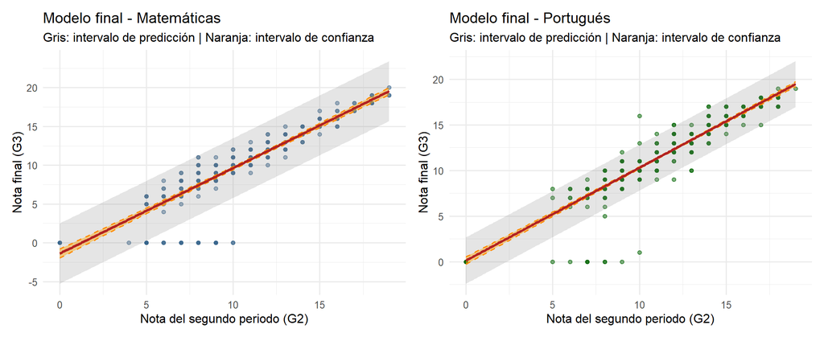

Figure 6.1: Predicción de G3 a partir de G2 con intervalo de confianza (naranja) e intervalo de predicción (gris) al 95%.

```r
graf_pred <- function(df, mod, nombre_base, color_puntos) {
  grilla <- tibble(G2 = seq(min(df$G2), max(df$G2), by = 0.1))

  ic_media <- predict(mod, newdata = grilla, interval = "confidence") |> as.data.frame()
  ip_ind <- predict(mod, newdata = grilla, interval = "prediction") |> as.data.frame()

  grilla <- bind_cols(
    grilla,
    fit = ic_media$fit,
    lwr_conf = ic_media$lwr,
    upr_conf = ic_media$upr,
    lwr_pred = ip_ind$lwr,
    upr_pred = ip_ind$upr
  )

  ggplot(df, aes(x = G2, y = G3)) +

    # Puntos
    geom_point(alpha = 0.5, color = color_puntos) +

    # Intervalo de predicción (más ancho, fondo)
    geom_ribbon(
      data = grilla,
      aes(x = G2, ymin = lwr_pred, ymax = upr_pred),
      fill = "gray60",
      alpha = 0.25,
      inherit.aes = FALSE
    ) +

    # Intervalo de confianza (más visible)
    geom_ribbon(
      data = grilla,
      aes(x = G2, ymin = lwr_conf, ymax = upr_conf),
      fill = "orange",
      alpha = 0.45,
      inherit.aes = FALSE
    ) +

    # Bordes del intervalo de confianza (esto lo hace MUCHO más claro 👀)
    geom_line(
      data = grilla,
      aes(x = G2, y = lwr_conf),
      color = "darkorange",
      linetype = "dashed",
      linewidth = 0.7,
      inherit.aes = FALSE
    ) +

    geom_line(
      data = grilla,
      aes(x = G2, y = upr_conf),
      color = "darkorange",
      linetype = "dashed",
      linewidth = 0.7,
      inherit.aes = FALSE
    ) +

    # Línea de predicción
    geom_line(
      data = grilla,
      aes(x = G2, y = fit),
      color = "firebrick",
      linewidth = 1.2,
      inherit.aes = FALSE
    ) +

    labs(
      title = paste("Modelo final -", nombre_base),
      subtitle = "Gris: intervalo de predicción | Naranja: intervalo de confianza",
      x = "Nota del segundo periodo (G2)",
      y = "Nota final (G3)"
    ) +

    theme_minimal(base_size = 12)
}

graf_pred(mat, mod_mat, "Matemáticas", "steelblue4") +
  graf_pred(por, mod_por, "Portugués", "darkgreen")
```

La tabla 6.1 muestra dos aspectos distintos. El **intervalo de confianza para la media** describe la nota media esperada de estudiantes con un valor específico de **G2**, mientras que el **intervalo de predicción** es más ancho porque incorpora la variabilidad individual. Además, para fines operativos de la aplicación se propone el módulo `prediccion_acotada()`, que recorta las salidas al rango real de la escala de notas **[0, 20]**. Este ajuste es razonable porque **G3** no puede ser menor que 0 ni mayor que 20, y evita predicciones imposibles en los extremos, especialmente en Matemáticas cuando **G2** es muy bajo.

# 7 Discusión y conclusiones

El análisis confirma que **G2 es el predictor cuantitativo más promisorio de G3** tanto en Matemáticas como en Lengua Portuguesa, mientras que **G1** ocupa consistentemente el segundo lugar. Esta evidencia sugiere que el desempeño previo constituye el mejor resumen disponible del rendimiento final dentro de la restricción metodológica de emplear una sola variable cuantitativa. En consecuencia, es posible construir un modelo lineal simple con alta capacidad explicativa, interpretación directa y utilidad práctica para la aplicación.

En Matemáticas, el modelo explica alrededor del **81.9%** de la variabilidad de G3; en Portugués explica aproximadamente **84.4%**. Las pendientes son positivas y altamente significativas en ambos casos, de modo que el comportamiento de la nota final sigue muy de cerca la nota del segundo periodo. Esto no significa que otras variables carezcan de interés, sino que, bajo la restricción metodológica de usar una sola variable cuantitativa, **G2 domina claramente a las demás**.

Respecto a los supuestos, el modelo presenta una situación frecuente en datos educativos discretos y acotados: el ajuste lineal es alto, pero la normalidad residual no se cumple estrictamente, la homocedasticidad también se ve afectada y, en el caso de Portugués, la independencia de los errores tampoco se sostiene por completo. Esto no invalida su utilidad predictiva, pero sí aconseja interpretar con cautela la inferencia clásica asociada al modelo. Se revisaron transformaciones y se estudió la influencia de observaciones atípicas; sin embargo, el modelo original en escala natural resultó el más conveniente por su equilibrio entre ajuste, interpretabilidad y uso práctico.

En términos aplicados, este resultado permite anticipar con buena precisión la nota final a partir del desempeño del segundo periodo y, por tanto, ofrece una herramienta útil para seguimiento académico temprano. No obstante, su uso debe entenderse como apoyo a la decisión y no como sustituto del juicio pedagógico, especialmente en presencia de trayectorias individuales atípicas.

Si bien el modelo permite generar predicciones puntuales de la nota final, es importante reconocer que estas estimaciones están sujetas a un grado de incertidumbre. Los intervalos de predicción reflejan esta variabilidad y muestran que, incluso con una misma variable predictora, el resultado puede variar considerablemente.

En términos prácticos, esto implica que el modelo es útil como herramienta orientativa, pero no debe interpretarse como un mecanismo determinista. Su mayor valor radica en identificar tendencias generales más que en predecir resultados individuales con total precisión.

Por tanto, el modelo final recomendado es:

- **Matemáticas:** `G3 = -1.393 + 1.102·G2`
- **Portugués:** `G3 = 0.122 + 1.018·G2`

Asimismo, conviene implementar la predicción acotada al rango **0–20** para no tener valores inadecuados de predicción.

**Observaciones importantes:**

- Más allá de los resultados obtenidos, es importante reconocer que el modelo de regresión lineal simple permite identificar tendencias generales en el rendimiento académico, pero no logra capturar toda la complejidad del fenómeno. El desempeño de un estudiante no depende únicamente de una variable cuantitativa, sino de múltiples factores que interactúan entre sí, como el contexto familiar, la motivación, los hábitos de estudio y las condiciones del entorno educativo.
- En este sentido, aunque el modelo presenta una relación estadísticamente significativa, su capacidad explicativa es parcial. Esto se evidencia en la dispersión de los datos y en el hecho de que no toda la variabilidad de la nota final es explicada por la variable predictora.
- El análisis de los supuestos del modelo evidencia que no todos se cumplen de manera adecuada. En particular, se observan desviaciones en los residuos que indican posibles problemas de homocedasticidad y/o normalidad. Estas situaciones afectan la validez de los intervalos de confianza y de las pruebas de hipótesis, ya que dichas inferencias dependen del cumplimiento de estos supuestos. En consecuencia, aunque el modelo permite identificar una tendencia general, sus resultados deben interpretarse con precaución.
- La presencia de valores atípicos sugiere que existen casos particulares que no siguen el patrón general. Estos casos pueden representar situaciones reales dentro del contexto educativo, lo que refuerza la idea de que el modelo no debe interpretarse de manera rígida, sino como una herramienta de aproximación.

**Todo esto implica que las conclusiones obtenidas no deben extrapolarse de manera directa a nuevos datos, especialmente si estos presentan características diferentes a las observadas en la muestra analizada.**

# 8 Referencias

- Cortez, P., & Silva, A. (2008). *Using Data Mining to Predict Secondary School Student Performance*.
- UCI Machine Learning Repository. *Student Performance Data Set*.
- Material del curso *Métodos y Simulación Estadística*, Unidad 3, regresión lineal simple.

# 9 Anexos

## 9.1 Anexo A. Código auxiliar para comparar transformaciones y polinomios

```r
# Función para marcar cumplimiento según p-valor
etiqueta_cumplimiento <- function(p) {
  ifelse(p > 0.05, "sí cumple", "no cumple")
}

# Función Box-Cox sobre la respuesta
ajustar_boxcox_y <- function(df) {
  df <- as.data.frame(df)
  df$G3_bc_base <- df$G3 + 1

  bc <- MASS::boxcox(
    G3_bc_base ~ G2,
    data = df,
    lambda = seq(-2, 2, by = 0.1),
    plotit = FALSE
  )

  lambda_opt <- bc$x[which.max(bc$y)]

  if (abs(lambda_opt) < 1e-8) {
    df$G3_trans <- log(df$G3_bc_base)
  } else {
    df$G3_trans <- (df$G3_bc_base^lambda_opt - 1) / lambda_opt
  }

  mod_bc <- lm(G3_trans ~ G2, data = df)

  list(modelo = mod_bc, lambda = lambda_opt)
}

comparar_transformaciones <- function(df, nombre_base) {
  df <- as.data.frame(df)

  # Box-Cox
  boxcox_y <- ajustar_boxcox_y(df)

  especificaciones <- list(

    # 1. Lineal
    list(
      tipo = "1. Lineal",
      modelo = "Lineal simple",
      ecuacion = "G3 ~ G2",
      ajuste = lm(G3 ~ G2, data = df),
      lambda = NA
    ),

    # 2. Lineal con transformaciones
    list(
      tipo = "2. Lineal con transformaciones",
      modelo = "Raíz en respuesta",
      ecuacion = "sqrt(G3) ~ G2",
      ajuste = lm(sqrt(G3) ~ G2, data = df),
      lambda = NA
    ),
    list(
      tipo = "2. Lineal con transformaciones",
      modelo = "Log en respuesta",
      ecuacion = "log(G3 + 1) ~ G2",
      ajuste = lm(log(G3 + 1) ~ G2, data = df),
      lambda = NA
    ),
    list(
      tipo = "2. Lineal con transformaciones",
      modelo = "Raíz en predictora",
      ecuacion = "G3 ~ sqrt(G2)",
      ajuste = lm(G3 ~ sqrt(G2), data = df),
      lambda = NA
    ),
    list(
      tipo = "2. Lineal con transformaciones",
      modelo = "Log en predictora",
      ecuacion = "G3 ~ log(G2 + 1)",
      ajuste = lm(G3 ~ log(G2 + 1), data = df),
      lambda = NA
    ),
    list(
      tipo = "2. Lineal con transformaciones",
      modelo = "Raíz en ambas",
      ecuacion = "sqrt(G3) ~ sqrt(G2)",
      ajuste = lm(sqrt(G3) ~ sqrt(G2), data = df),
      lambda = NA
    ),
    list(
      tipo = "2. Lineal con transformaciones",
      modelo = "Log en ambas",
      ecuacion = "log(G3 + 1) ~ log(G2 + 1)",
      ajuste = lm(log(G3 + 1) ~ log(G2 + 1), data = df),
      lambda = NA
    ),
    list(
      tipo = "2. Lineal con transformaciones",
      modelo = "Y log y X raíz",
      ecuacion = "log(G3 + 1) ~ sqrt(G2)",
      ajuste = lm(log(G3 + 1) ~ sqrt(G2), data = df),
      lambda = NA
    ),
    list(
      tipo = "2. Lineal con transformaciones",
      modelo = "Y raíz y X log",
      ecuacion = "sqrt(G3) ~ log(G2 + 1)",
      ajuste = lm(sqrt(G3) ~ log(G2 + 1), data = df),
      lambda = NA
    ),
    list(
      tipo = "2. Lineal con transformaciones",
      modelo = "Box-Cox en respuesta",
      ecuacion = "BC(G3 + 1) ~ G2",
      ajuste = boxcox_y$modelo,
      lambda = round(boxcox_y$lambda, 4)
    ),

    # 3. Polinómicos
    list(
      tipo = "3. Polinómicos",
      modelo = "Polinómico grado 2",
      ecuacion = "G3 ~ G2 + I(G2^2)",
      ajuste = lm(G3 ~ G2 + I(G2^2), data = df),
      lambda = NA
    ),
    list(
      tipo = "3. Polinómicos",
      modelo = "Polinómico grado 3",
      ecuacion = "G3 ~ G2 + I(G2^2) + I(G2^3)",
      ajuste = lm(G3 ~ G2 + I(G2^2) + I(G2^3), data = df),
      lambda = NA
    ),

    # 4. Polinómicos con transformaciones
    list(
      tipo = "4. Polinómicos con transformaciones",
      modelo = "Polinómico grado 2 con log en respuesta",
      ecuacion = "log(G3 + 1) ~ G2 + I(G2^2)",
      ajuste = lm(log(G3 + 1) ~ G2 + I(G2^2), data = df),
      lambda = NA
    ),
    list(
      tipo = "4. Polinómicos con transformaciones",
      modelo = "Polinómico grado 2 con raíz en respuesta",
      ecuacion = "sqrt(G3) ~ G2 + I(G2^2)",
      ajuste = lm(sqrt(G3) ~ G2 + I(G2^2), data = df),
      lambda = NA
    ),
    list(
      tipo = "4. Polinómicos con transformaciones",
      modelo = "Polinómico grado 2 con log en predictora",
      ecuacion = "G3 ~ log(G2 + 1) + I(log(G2 + 1)^2)",
      ajuste = lm(G3 ~ log(G2 + 1) + I(log(G2 + 1)^2), data = df),
      lambda = NA
    ),
    list(
      tipo = "4. Polinómicos con transformaciones",
      modelo = "Polinómico grado 2 con raíz en predictora",
      ecuacion = "G3 ~ sqrt(G2) + I(sqrt(G2)^2)",
      ajuste = lm(G3 ~ sqrt(G2) + I(sqrt(G2)^2), data = df),
      lambda = NA
    ),
    list(
      tipo = "4. Polinómicos con transformaciones",
      modelo = "Polinómico grado 2 con log en ambas",
      ecuacion = "log(G3 + 1) ~ log(G2 + 1) + I(log(G2 + 1)^2)",
      ajuste = lm(log(G3 + 1) ~ log(G2 + 1) + I(log(G2 + 1)^2), data = df),
      lambda = NA
    )
  )

  purrr::map_dfr(especificaciones, function(spec) {
    mod <- spec$ajuste

    p_shapiro <- shapiro.test(residuals(mod))$p.value
    p_bp <- lmtest::bptest(mod)$p.value
    p_dw <- lmtest::dwtest(mod)$p.value

    tibble::tibble(
      Base = nombre_base,
      `Tipo de modelo` = spec$tipo,
      `Comentario / familia` = spec$modelo,
      `Ecuación del modelo` = spec$ecuacion,
      `Lambda Box-Cox respuesta` = spec$lambda,
      `R²` = summary(mod)$r.squared,
      `R² ajustado` = summary(mod)$adj.r.squared,
      `Error estándar residual` = sigma(mod),
      `Prueba de Shapiro-Wilk p-valor (Normalidad)` =
        paste0(sprintf("%.5f", p_shapiro), " (", etiqueta_cumplimiento(p_shapiro), ")"),
      `Prueba de Breusch-Pagan p-valor (Homocedasticidad)` =
        paste0(sprintf("%.5f", p_bp), " (", etiqueta_cumplimiento(p_bp), ")"),
      `Prueba de Durbin-Watson p-valor (Independencia)` =
        paste0(sprintf("%.5f", p_dw), " (", etiqueta_cumplimiento(p_dw), ")")
    )
  })
}

tabla_transformaciones <- dplyr::bind_rows(
  comparar_transformaciones(mat, "Matemáticas"),
  comparar_transformaciones(por, "Portugués")
) |>
  dplyr::mutate(
    orden_tipo = dplyr::case_when(
      `Tipo de modelo` == "1. Lineal" ~ 1,
      `Tipo de modelo` == "2. Lineal con transformaciones" ~ 2,
      `Tipo de modelo` == "3. Polinómicos" ~ 3,
      `Tipo de modelo` == "4. Polinómicos con transformaciones" ~ 4
    )
  ) |>
  dplyr::arrange(Base, orden_tipo, dplyr::desc(`R² ajustado`)) |>
  dplyr::select(-orden_tipo)

knitr::kable(
  tabla_transformaciones,
  caption = "Comparación integral de especificaciones del modelo, organizada en modelos lineales, lineales con transformaciones, polinómicos y polinómicos con transformaciones, incluyendo calidad de ajuste y verificación de supuestos estadísticos.",
  format = "html",
  escape = FALSE
) |>
  kableExtra::kable_styling(
    bootstrap_options = c("striped", "hover", "bordered"),
    full_width = FALSE,
    font_size = 10
  ) |>
  kableExtra::scroll_box(width = "100%", height = "100%")
```

Table 9.1: Comparación integral de especificaciones del modelo, organizada en modelos lineales, lineales con transformaciones, polinómicos y polinómicos con transformaciones, incluyendo calidad de ajuste y verificación de supuestos estadísticos.

Base

Tipo de modelo

Comentario / familia

Ecuación del modelo

Lambda Box-Cox respuesta

R²

R² ajustado

Error estándar residual

Prueba de Shapiro-Wilk p-valor (Normalidad)

Prueba de Breusch-Pagan p-valor (Homocedasticidad)

Prueba de Durbin-Watson p-valor (Independencia)

Matemáticas

1. Lineal

Lineal simple

G3 ~ G2

NA

0.8187861

0.8183250

1.9527645

0.00000 (no cumple)

0.00011 (no cumple)

0.09125 (sí cumple)

Matemáticas

2. Lineal con transformaciones

Box-Cox en respuesta

BC(G3 + 1) ~ G2

1.5

0.8598029

0.8594462

5.2566722

0.00000 (no cumple)

0.00000 (no cumple)

0.03004 (no cumple)

Matemáticas

2. Lineal con transformaciones

Raíz en predictora

G3 ~ sqrt(G2)

NA

0.7015605

0.7008011

2.5060069

0.00000 (no cumple)

0.00000 (no cumple)

0.13406 (sí cumple)

Matemáticas

2. Lineal con transformaciones

Raíz en ambas

sqrt(G3) ~ sqrt(G2)

NA

0.6377783

0.6368566

0.6587980

0.00000 (no cumple)

0.00027 (no cumple)

0.30400 (sí cumple)

Matemáticas

2. Lineal con transformaciones

Raíz en respuesta

sqrt(G3) ~ G2

NA

0.6366105

0.6356858

0.6598592

0.00000 (no cumple)

0.00000 (no cumple)

0.20193 (sí cumple)

Matemáticas

2. Lineal con transformaciones

Log en predictora

G3 ~ log(G2 + 1)

NA

0.6140781

0.6130961

2.8497306

0.00000 (no cumple)

0.00000 (no cumple)

0.24523 (sí cumple)

Matemáticas

2. Lineal con transformaciones

Y raíz y X log

sqrt(G3) ~ log(G2 + 1)

NA

0.6004290

0.5994123

0.6919297

0.00000 (no cumple)

0.00045 (no cumple)

0.34507 (sí cumple)

Matemáticas

2. Lineal con transformaciones

Y log y X raíz

log(G3 + 1) ~ sqrt(G2)

NA

0.5912758

0.5902358

0.4990106

0.00000 (no cumple)

0.00074 (no cumple)

0.35620 (sí cumple)

Matemáticas

2. Lineal con transformaciones

Log en ambas

log(G3 + 1) ~ log(G2 + 1)

NA

0.5715830

0.5704929

0.5108906

0.00000 (no cumple)

0.00185 (no cumple)

0.38387 (sí cumple)

Matemáticas

2. Lineal con transformaciones

Log en respuesta

log(G3 + 1) ~ G2

NA

0.5550976

0.5539655

0.5206273

0.00000 (no cumple)

0.00000 (no cumple)

0.21940 (sí cumple)

Matemáticas

3. Polinómicos

Polinómico grado 3

G3 ~ G2 + I(G2^2) + I(G2^3)

NA

0.8236431

0.8222900

1.9313378

0.00000 (no cumple)

0.00000 (no cumple)

0.05947 (sí cumple)

Matemáticas

3. Polinómicos

Polinómico grado 2

G3 ~ G2 + I(G2^2)

NA

0.8196634

0.8187433

1.9505149

0.00000 (no cumple)

0.00010 (no cumple)

0.09959 (sí cumple)

Matemáticas

4. Polinómicos con transformaciones

Polinómico grado 2 con log en predictora

G3 ~ log(G2 + 1) + I(log(G2 + 1)^2)

NA

0.8249175

0.8240242

1.9218907

0.00000 (no cumple)

0.00000 (no cumple)

0.03323 (no cumple)

Matemáticas

4. Polinómicos con transformaciones

Polinómico grado 2 con raíz en predictora

G3 ~ sqrt(G2) + I(sqrt(G2)^2)

NA

0.8220021

0.8210939

1.9378260

0.00000 (no cumple)

0.00000 (no cumple)

0.08131 (sí cumple)

Matemáticas

4. Polinómicos con transformaciones

Polinómico grado 2 con raíz en respuesta

sqrt(G3) ~ G2 + I(G2^2)

NA

0.6661740

0.6644708

0.6332546

0.00000 (no cumple)

0.00001 (no cumple)

0.19669 (sí cumple)

Matemáticas

4. Polinómicos con transformaciones

Polinómico grado 2 con log en respuesta

log(G3 + 1) ~ G2 + I(G2^2)

NA

0.6119638

0.6099840

0.4868374

0.00000 (no cumple)

0.00000 (no cumple)

0.23358 (sí cumple)

Matemáticas

4. Polinómicos con transformaciones

Polinómico grado 2 con log en ambas

log(G3 + 1) ~ log(G2 + 1) + I(log(G2 + 1)^2)

NA

0.6020776

0.6000474

0.4930001

0.00000 (no cumple)

0.00000 (no cumple)

0.29329 (sí cumple)

Portugués

1. Lineal

Lineal simple

G3 ~ G2

NA

0.8437304

0.8434889

1.2780955

0.00000 (no cumple)

0.00007 (no cumple)

0.02463 (no cumple)

Portugués

2. Lineal con transformaciones

Box-Cox en respuesta

BC(G3 + 1) ~ G2

1.6

0.8701887

0.8699881

5.0029088

0.00000 (no cumple)

0.00000 (no cumple)

0.01870 (no cumple)

Portugués

2. Lineal con transformaciones

Raíz en predictora

G3 ~ sqrt(G2)

NA

0.7708435

0.7704893

1.5477192

0.00000 (no cumple)

0.00000 (no cumple)

0.00549 (no cumple)

Portugués

2. Lineal con transformaciones

Raíz en ambas

sqrt(G3) ~ sqrt(G2)

NA

0.7274014

0.7269801

0.3402398

0.00000 (no cumple)

0.00013 (no cumple)

0.02301 (no cumple)

Portugués

2. Lineal con transformaciones

Y raíz y X log

sqrt(G3) ~ log(G2 + 1)

NA

0.7063453

0.7058915

0.3531358

0.00000 (no cumple)

0.00002 (no cumple)

0.01233 (no cumple)

Portugués

2. Lineal con transformaciones

Log en predictora

G3 ~ log(G2 + 1)

NA

0.6807641

0.6802707

1.8267620

0.00000 (no cumple)

0.00000 (no cumple)

0.00059 (no cumple)

Portugués

2. Lineal con transformaciones

Raíz en respuesta

sqrt(G3) ~ G2

NA

0.6669184

0.6664036

0.3760959

0.00000 (no cumple)

0.00000 (no cumple)

0.03267 (no cumple)

Portugués

2. Lineal con transformaciones

Log en ambas

log(G3 + 1) ~ log(G2 + 1)

NA

0.6663723

0.6658566

0.2548349

0.00000 (no cumple)

0.00048 (no cumple)

0.02503 (no cumple)

Portugués

2. Lineal con transformaciones

Y log y X raíz

log(G3 + 1) ~ sqrt(G2)

NA

0.6574140

0.6568845

0.2582335

0.00000 (no cumple)

0.00008 (no cumple)

0.02898 (no cumple)

Portugués

2. Lineal con transformaciones

Log en respuesta

log(G3 + 1) ~ G2

NA

0.5516676

0.5509747

0.2954118

0.00000 (no cumple)

0.00000 (no cumple)

0.03939 (no cumple)

Portugués

3. Polinómicos

Polinómico grado 3

G3 ~ G2 + I(G2^2) + I(G2^3)

NA

0.8459640

0.8452475

1.2708947

0.00000 (no cumple)

0.00000 (no cumple)

0.06101 (sí cumple)

Portugués

3. Polinómicos

Polinómico grado 2

G3 ~ G2 + I(G2^2)

NA

0.8446594

0.8441784

1.2752770

0.00000 (no cumple)

0.00024 (no cumple)

0.03363 (no cumple)

Portugués

4. Polinómicos con transformaciones

Polinómico grado 2 con log en predictora

G3 ~ log(G2 + 1) + I(log(G2 + 1)^2)

NA

0.8457589

0.8452814

1.2707556

0.00000 (no cumple)

0.00000 (no cumple)

0.08226 (sí cumple)

Portugués

4. Polinómicos con transformaciones

Polinómico grado 2 con raíz en predictora

G3 ~ sqrt(G2) + I(sqrt(G2)^2)

NA

0.8438901

0.8434068

1.2784307

0.00000 (no cumple)

0.00010 (no cumple)

0.02460 (no cumple)

Portugués

4. Polinómicos con transformaciones

Polinómico grado 2 con raíz en respuesta

sqrt(G3) ~ G2 + I(G2^2)

NA

0.7340702

0.7332469

0.3363122

0.00000 (no cumple)

0.00001 (no cumple)

0.14493 (sí cumple)

Portugués

4. Polinómicos con transformaciones

Polinómico grado 2 con log en respuesta

log(G3 + 1) ~ G2 + I(G2^2)

NA

0.6735782

0.6725676

0.2522628

0.00000 (no cumple)

0.00001 (no cumple)

0.19354 (sí cumple)

Portugués

4. Polinómicos con transformaciones

Polinómico grado 2 con log en ambas

log(G3 + 1) ~ log(G2 + 1) + I(log(G2 + 1)^2)

NA

0.6685054

0.6674791

0.2542154

0.00000 (no cumple)

0.00000 (no cumple)

0.03215 (no cumple)

De la Tabla 9.1 se observa diferentes iteraciones con transformaciones, no es estrictamente necesario incluir modelos polinómicos, ya que la relación entre G2 y G3 responde a una lógica de continuidad académica que suele ser aproximadamente lineal. Los problemas identificados en los supuestos (normalidad y homocedasticidad) no implican necesariamente una relación no lineal, sino más bien características propias de la dispersión de los datos. Aún así decidi explorarlos para ver si había alguna mejora pero no, incluyendo hasta combinaciones de polinomicos con transformaciones.

## 9.2 Anexo B. Código para identificar observaciones influyentes

```r
detalle_influencia <- function(mod, df, nombre_base, n_mostrar = 10) {
  n <- nobs(mod)
  p <- length(coef(mod))

  broom::augment(mod) |>
    dplyr::mutate(
      G2 = df$G2,
      G3 = df$G3,
      Observación = paste0(
        "Obs ", row_number(),
        " (G2=", G2, ", G3=", G3, ")"
      ),
      leverage = hatvalues(mod),
      residuo_studentizado = rstudent(mod),
      distancia_cook = cooks.distance(mod),
      observacion_atipica = ifelse(abs(residuo_studentizado) > 3, "Sí", "No"),
      leverage_alto = ifelse(leverage > (2 * p / n), "Sí", "No"),
      influencia_alta = ifelse(distancia_cook > (4 / n), "Sí", "No")
    ) |>
    dplyr::arrange(desc(distancia_cook)) |>
    dplyr::select(
      Observación,
      `Valor ajustado` = .fitted,
      `Residuo` = .resid,
      `Leverage` = leverage,
      `Residuo studentizado` = residuo_studentizado,
      `Distancia de Cook` = distancia_cook,
      Atípica = observacion_atipica,
      `Leverage alto` = leverage_alto,
      Influyente = influencia_alta
    ) |>
    dplyr::slice_head(n = n_mostrar) |>
    dplyr::mutate(Base = nombre_base, .before = 1)
}

tabla_influencia_detalle <- dplyr::bind_rows(
  detalle_influencia(mod_mat, mat, "Matemáticas"),
  detalle_influencia(mod_por, por, "Portugués")
)

knitr::kable(
  tabla_influencia_detalle,
  caption = "Observaciones con mayor influencia potencial, identificadas por su posición en el dataset y sus valores de G2 y G3.",
  digits = 4,
  format = "html"
) |>
  kableExtra::kable_styling(
    bootstrap_options = c("striped", "hover", "bordered"),
    full_width = FALSE,
    font_size = 10
  )
```

Table 9.2: Observaciones con mayor influencia potencial, identificadas por su posición en el dataset y sus valores de G2 y G3.

| Base | Observación | Valor ajustado | Residuo | Leverage | Residuo studentizado | Distancia de Cook | Atípica | Leverage alto | Influyente |
| --- | --- | --- | --- | --- | --- | --- | --- | --- | --- |
| Matemáticas | Obs 265 (G2=10, G3=0) | 9.6284 | -9.6284 | 0.0026 | -5.0912 | 0.0321 | Sí | No | Sí |
| Matemáticas | Obs 342 (G2=10, G3=0) | 9.6284 | -9.6284 | 0.0026 | -5.0912 | 0.0321 | Sí | No | Sí |
| Matemáticas | Obs 141 (G2=9, G3=0) | 8.5263 | -8.5263 | 0.0031 | -4.4777 | 0.0293 | Sí | No | Sí |
| Matemáticas | Obs 260 (G2=9, G3=0) | 8.5263 | -8.5263 | 0.0031 | -4.4777 | 0.0293 | Sí | No | Sí |
| Matemáticas | Obs 297 (G2=9, G3=0) | 8.5263 | -8.5263 | 0.0031 | -4.4777 | 0.0293 | Sí | No | Sí |
| Matemáticas | Obs 311 (G2=9, G3=0) | 8.5263 | -8.5263 | 0.0031 | -4.4777 | 0.0293 | Sí | No | Sí |
| Matemáticas | Obs 335 (G2=9, G3=0) | 8.5263 | -8.5263 | 0.0031 | -4.4777 | 0.0293 | Sí | No | Sí |
| Matemáticas | Obs 317 (G2=8, G3=0) | 7.4241 | -7.4241 | 0.0039 | -3.8766 | 0.0281 | Sí | No | Sí |
| Matemáticas | Obs 334 (G2=8, G3=0) | 7.4241 | -7.4241 | 0.0039 | -3.8766 | 0.0281 | Sí | No | Sí |
| Matemáticas | Obs 338 (G2=8, G3=0) | 7.4241 | -7.4241 | 0.0039 | -3.8766 | 0.0281 | Sí | No | Sí |
| Portugués | Obs 520 (G2=7, G3=0) | 7.2514 | -7.2514 | 0.0053 | -5.8321 | 0.0868 | Sí | No | Sí |
| Portugués | Obs 638 (G2=7, G3=0) | 7.2514 | -7.2514 | 0.0053 | -5.8321 | 0.0868 | Sí | No | Sí |
| Portugués | Obs 641 (G2=7, G3=0) | 7.2514 | -7.2514 | 0.0053 | -5.8321 | 0.0868 | Sí | No | Sí |
| Portugués | Obs 584 (G2=6, G3=0) | 6.2329 | -6.2329 | 0.0072 | -4.9837 | 0.0866 | Sí | Sí | Sí |
| Portugués | Obs 587 (G2=8, G3=0) | 8.2699 | -8.2699 | 0.0039 | -6.6992 | 0.0814 | Sí | No | Sí |
| Portugués | Obs 640 (G2=8, G3=0) | 8.2699 | -8.2699 | 0.0039 | -6.6992 | 0.0814 | Sí | No | Sí |
| Portugués | Obs 627 (G2=5, G3=0) | 5.2144 | -5.2144 | 0.0094 | -4.1502 | 0.0796 | Sí | Sí | Sí |
| Portugués | Obs 164 (G2=9, G3=0) | 9.2884 | -9.2884 | 0.0027 | -7.5889 | 0.0728 | Sí | No | Sí |
| Portugués | Obs 173 (G2=10, G3=1) | 10.3069 | -9.3069 | 0.0020 | -7.6023 | 0.0529 | Sí | No | Sí |
| Portugués | Obs 519 (G2=5, G3=8) | 5.2144 | 2.7856 | 0.0094 | 2.1962 | 0.0227 | No | Sí | Sí |

En la Tabla 9.2 se identificaron algunas observaciones con valores de distancia de Cook superiores al umbral teórico 4/n, lo que indica que ejercen una influencia relativamente mayor sobre el modelo. Sin embargo, estos valores no son lo suficientemente altos como para considerarse extremos, y además corresponden a un número reducido de casos. Dado que el objetivo del análisis es predecir la nota final en un contexto educativo real, estas observaciones representan variabilidad propia del desempeño de los estudiantes y no errores en los datos. Por esta razón, no se justifica su eliminación, ya que excluirlas podría sesgar el modelo y reducir su capacidad de representar adecuadamente la realidad académica.